# DK Forest LiDAR - Random Forest Model Performance

Jakob Assmann

09/08/2022

## Models trained using BIOWIDE stratification

For these models the training data was split according to the BIOWIDE stratification.

### Variable importance

Variable importance for this random forest model, determined using the “permutation” option in ranger.

|  | Overall |
| --- | --- |
| Sand_utm32_10m | 100.000000 |
| treetype_bjer_dec | 82.402128 |
| dtm_10m | 77.419004 |
| Clay_utm32_10m | 70.345552 |
| dtm_10m_sd_110m | 57.163281 |
| ns_groundwater_summer_utm32_10m | 56.787379 |
| Soc_utm32_10m | 38.041657 |
| amplitude_sd | 37.983167 |
| canopy_height | 36.898430 |
| normalized_z_sd | 35.367769 |
| openness_difference | 30.409109 |
| slope | 20.910563 |
| ns_groundwater_summer_sd_110m | 16.561303 |
| vegetation_density | 15.630589 |
| amplitude_mean | 13.397601 |
| solar_radiation | 12.448666 |
| canopy_height_sd_110m | 4.933190 |
| vegetation_density_sd_110m | 3.406289 |
| foliage_height_diversity | 0.000000 |

### Performance in BIOWIDE regions:

Performance map based on the independent validation data:

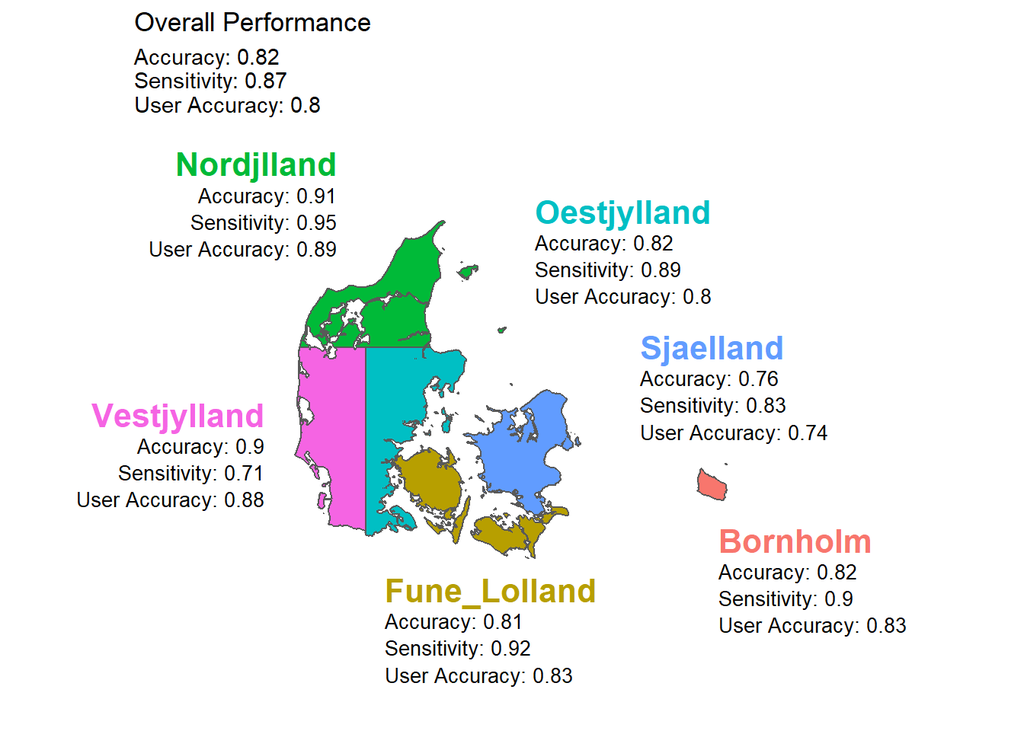

Performance table based on the independent validation data:

| Measure | Overall | Bornholm | Fune_Lolland | Nordjlland | Oestjylland | Sjaelland | Vestjylland |
| --- | --- | --- | --- | --- | --- | --- | --- |
| Accuracy | 0.82 | 0.82 | 0.81 | 0.91 | 0.82 | 0.76 | 0.90 |
| Error | 0.18 | 0.18 | 0.19 | 0.09 | 0.18 | 0.24 | 0.10 |
| Sensitivity (True Positive Rate) | 0.87 | 0.90 | 0.92 | 0.95 | 0.89 | 0.83 | 0.71 |
| Specificity (True Negative Rate) | 0.78 | 0.69 | 0.60 | 0.86 | 0.74 | 0.69 | 0.96 |
| Fall-out (False Positive Rate) | 0.22 | 0.31 | 0.40 | 0.14 | 0.26 | 0.31 | 0.04 |
| Positive predictive value (User Accuracy) | 0.80 | 0.83 | 0.83 | 0.89 | 0.80 | 0.74 | 0.88 |

Performance table based on the dependent training data:

| Measure | Overall | Bornholm | Fune_Lolland | Nordjlland | Oestjylland | Sjaelland | Vestjylland |
| --- | --- | --- | --- | --- | --- | --- | --- |
| Accuracy | 1 | 1 | 1 | 1 | 1 | 1 | 1 |
| Error | 0 | 0 | 0 | 0 | 0 | 0 | 0 |
| Sensitivity (True Positive Rate) | 1 | 1 | 1 | 1 | 1 | 1 | 1 |
| Specificity (True Negative Rate) | 1 | 1 | 1 | 1 | 1 | 1 | 1 |
| Fall-out (False Positive Rate) | 0 | 0 | 0 | 0 | 0 | 0 | 0 |
| Positive predictive value (User Accuracy) | 1 | 1 | 1 | 1 | 1 | 1 | 1 |

### Performance in Derek’s regions:

Performance map based on the independent validation data:

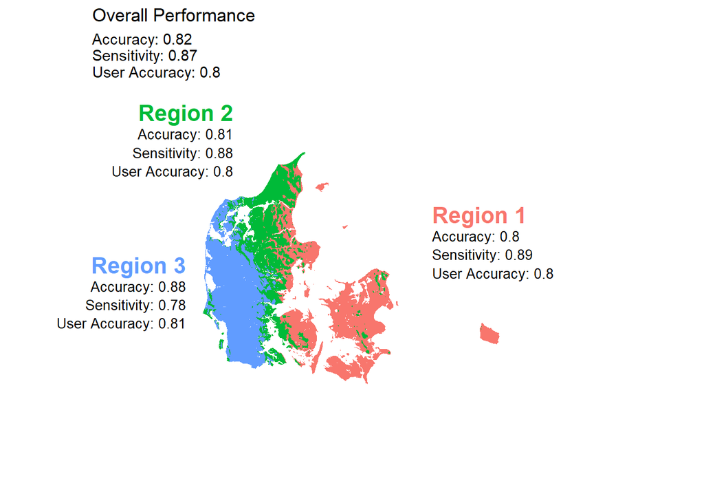

Performance table based on the independent validation data:

| Measure | Overall | Region 1 | Region 2 | Region 3 |
| --- | --- | --- | --- | --- |
| Accuracy | 0.82 | 0.80 | 0.81 | 0.88 |
| Error | 0.18 | 0.20 | 0.19 | 0.12 |
| Sensitivity (True Positive Rate) | 0.87 | 0.89 | 0.88 | 0.78 |
| Specificity (True Negative Rate) | 0.78 | 0.68 | 0.71 | 0.92 |
| Fall-out (False Positive Rate) | 0.22 | 0.32 | 0.29 | 0.08 |
| Positive predictive value (User Accuracy) | 0.80 | 0.80 | 0.80 | 0.81 |

Performance table based on the dependent training data:

| Measure | Overall | Region 1 | Region 2 | Region 3 |
| --- | --- | --- | --- | --- |
| Accuracy | 1 | 1 | 1 | 1 |
| Error | 0 | 0 | 0 | 0 |
| Sensitivity (True Positive Rate) | 1 | 1 | 1 | 1 |
| Specificity (True Negative Rate) | 1 | 1 | 1 | 1 |
| Fall-out (False Positive Rate) | 0 | 0 | 0 | 0 |
| Positive predictive value (User Accuracy) | 1 | 1 | 1 | 1 |

### Performance by forest type (boradleaf vs. coniferous)

Performance table based on the independent validation data:

| Measure | Overall | Broadleaf | Coniferous |
| --- | --- | --- | --- |
| Accuracy | 0.82 | 0.81 | 0.87 |
| Error | 0.18 | 0.19 | 0.13 |
| Sensitivity (True Positive Rate) | 0.87 | 0.91 | 0.57 |
| Specificity (True Negative Rate) | 0.78 | 0.66 | 0.96 |
| Fall-out (False Positive Rate) | 0.22 | 0.34 | 0.04 |
| Positive predictive value (User Accuracy) | 0.80 | 0.80 | 0.83 |

Performance table based on the dependent training data:

| Measure | Overall | Broadleaf | Coniferous |
| --- | --- | --- | --- |
| Accuracy | 1 | 1 | 1 |
| Error | 0 | 0 | 0 |
| Sensitivity (True Positive Rate) | 1 | 1 | 1 |
| Specificity (True Negative Rate) | 1 | 1 | 1 |
| Fall-out (False Positive Rate) | 0 | 0 | 0 |
| Positive predictive value (User Accuracy) | 1 | 1 | 1 |

## Models trained using Derek’s stratification

### Variable importance

Variable importance for this random forest model, determined using the “permutation” option in ranger.

|  | Overall |
| --- | --- |
| Sand_utm32_10m | 100.000000 |
| treetype_bjer_dec | 81.570818 |
| dtm_10m | 73.198738 |
| Clay_utm32_10m | 69.218368 |
| dtm_10m_sd_110m | 58.622528 |
| ns_groundwater_summer_utm32_10m | 56.875166 |
| amplitude_sd | 39.117492 |
| Soc_utm32_10m | 37.597694 |
| canopy_height | 36.925847 |
| normalized_z_sd | 34.734356 |
| openness_difference | 30.391050 |
| slope | 19.174338 |
| ns_groundwater_summer_sd_110m | 16.546973 |
| amplitude_mean | 14.016066 |
| vegetation_density | 13.985474 |
| solar_radiation | 11.460056 |
| canopy_height_sd_110m | 4.549356 |
| vegetation_density_sd_110m | 3.270389 |
| foliage_height_diversity | 0.000000 |

### Performance in BIOWIDE regions:

Performance map based on the independent validation data:

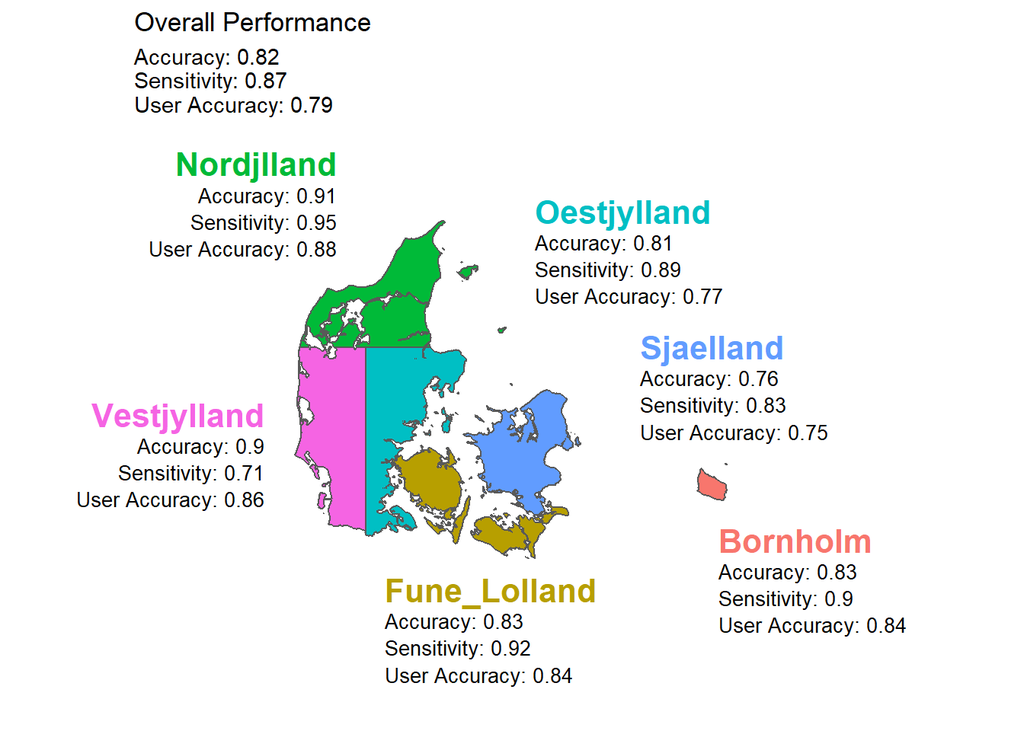

Performance table based on the independent validation data:

| Measure | Overall | Bornholm | Fune_Lolland | Nordjlland | Oestjylland | Sjaelland | Vestjylland |
| --- | --- | --- | --- | --- | --- | --- | --- |
| Accuracy | 0.82 | 0.83 | 0.83 | 0.91 | 0.81 | 0.76 | 0.90 |
| Error | 0.18 | 0.17 | 0.17 | 0.09 | 0.19 | 0.24 | 0.10 |
| Sensitivity (True Positive Rate) | 0.87 | 0.90 | 0.92 | 0.95 | 0.89 | 0.83 | 0.71 |
| Specificity (True Negative Rate) | 0.77 | 0.70 | 0.64 | 0.85 | 0.71 | 0.70 | 0.96 |
| Fall-out (False Positive Rate) | 0.23 | 0.30 | 0.36 | 0.15 | 0.29 | 0.30 | 0.04 |
| Positive predictive value (User Accuracy) | 0.79 | 0.84 | 0.84 | 0.88 | 0.77 | 0.75 | 0.86 |

Performance table based on the dependent training data:

| Measure | Overall | Bornholm | Fune_Lolland | Nordjlland | Oestjylland | Sjaelland | Vestjylland |
| --- | --- | --- | --- | --- | --- | --- | --- |
| Accuracy | 1 | 1 | 1 | 1 | 1 | 1 | 1 |
| Error | 0 | 0 | 0 | 0 | 0 | 0 | 0 |
| Sensitivity (True Positive Rate) | 1 | 1 | 1 | 1 | 1 | 1 | 1 |
| Specificity (True Negative Rate) | 1 | 1 | 1 | 1 | 1 | 1 | 1 |
| Fall-out (False Positive Rate) | 0 | 0 | 0 | 0 | 0 | 0 | 0 |
| Positive predictive value (User Accuracy) | 1 | 1 | 1 | 1 | 1 | 1 | 1 |

### Perfromance in Derek’s regions:

Performance map based on the independent validation data:

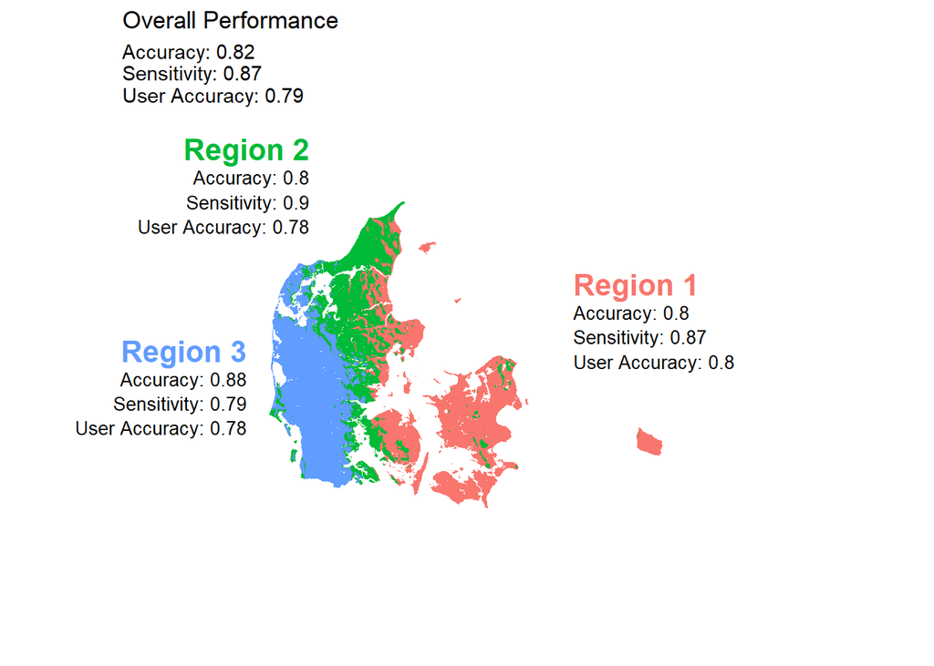

Performance table based on the independent validation data:

| Measure | Overall | Region 1 | Region 2 | Region 3 |
| --- | --- | --- | --- | --- |
| Accuracy | 0.82 | 0.80 | 0.80 | 0.88 |
| Error | 0.18 | 0.20 | 0.20 | 0.12 |
| Sensitivity (True Positive Rate) | 0.87 | 0.87 | 0.90 | 0.79 |
| Specificity (True Negative Rate) | 0.77 | 0.69 | 0.68 | 0.92 |
| Fall-out (False Positive Rate) | 0.23 | 0.31 | 0.32 | 0.08 |
| Positive predictive value (User Accuracy) | 0.79 | 0.80 | 0.78 | 0.78 |

Performance table based on the dependent training data:

| Measure | Overall | Region 1 | Region 2 | Region 3 |
| --- | --- | --- | --- | --- |
| Accuracy | 1 | 1 | 1 | 1 |
| Error | 0 | 0 | 0 | 0 |
| Sensitivity (True Positive Rate) | 1 | 1 | 1 | 1 |
| Specificity (True Negative Rate) | 1 | 1 | 1 | 1 |
| Fall-out (False Positive Rate) | 0 | 0 | 0 | 0 |
| Positive predictive value (User Accuracy) | 1 | 1 | 1 | 1 |

### Performance by forest type (boradleaf vs. coniferous)

Performance table based on the independent validation data:

| Measure | Overall | Broadleaf | Coniferous |
| --- | --- | --- | --- |
| Accuracy | 0.82 | 0.80 | 0.88 |
| Error | 0.18 | 0.20 | 0.12 |
| Sensitivity (True Positive Rate) | 0.87 | 0.91 | 0.60 |
| Specificity (True Negative Rate) | 0.77 | 0.65 | 0.96 |
| Fall-out (False Positive Rate) | 0.23 | 0.35 | 0.04 |
| Positive predictive value (User Accuracy) | 0.79 | 0.79 | 0.80 |

Performance table based on the dependent training data:

| Measure | Overall | Broadleaf | Coniferous |
| --- | --- | --- | --- |
| Accuracy | 1 | 1 | 1 |
| Error | 0 | 0 | 0 |
| Sensitivity (True Positive Rate) | 1 | 1 | 1 |
| Specificity (True Negative Rate) | 1 | 1 | 1 |
| Fall-out (False Positive Rate) | 0 | 0 | 0 |
| Positive predictive value (User Accuracy) | 1 | 1 | 1 |